# Worksheet: Making Fair Comparisons

Lessons from the UNL Metrics Seminar

Author

Dianne Cook

## 🎯 Objectives

These exercises draw on the *Comparisons* section of the [2025 UNL Metrics Seminar](https://unl-statistics.github.io/2025-metrics-seminar/#/comparisons). By the end of the worksheet you should be able to:

- Explain what the Scholarly Research Index (SRI) measures and why field-specific percentiles are preferable to raw SRI values.
- Recognise when a comparison is unfair because structurally different groups are placed on the same scale.
- Construct and interpret visualisations that make cross-group comparisons more transparent.
- Articulate a constructive use of performance gaps (investment, not punishment).

## 🧩 Tasks

#### 1. What does the SRI measure, and what are its limits for cross-field comparison?

The Scholarly Research Index (SRI) is a composite metric created by Academic Analytics. It combines counts of awards, books, citations, articles, grants, grant dollars, clinical trials, and patents into a single score.

1. List **two reasons** why comparing the raw SRI of a Statistics department directly with the raw SRI of a Physics department could be misleading.
2. The seminar suggests using *SRI percentiles within field* rather than raw SRI values. Explain in plain language why this is a better approach.

**SolutionSolution**

**a.** Any two of:

- Citation and grant norms differ enormously across disciplines. Physics departments may have access to large federal grants (e.g., NSF, DOE) and benefit from high-energy physics collaborations that generate thousands of co-authored, highly cited papers — none of which reflects the quality of research in Statistics vs Physics.
- The denominator matters: a Physics department may have three times as many faculty as a Statistics department, so raw totals naturally favour larger units.
- Patents and clinical trials are essentially zero for most Statistics departments, dragging their SRI down relative to engineering or medicine-adjacent fields regardless of research quality.

**b.** A percentile within field tells you where a department stands *relative to comparable departments in the same discipline*. A Statistics department at the 80th SRI percentile among Statistics departments is clearly high-performing, even if its raw SRI is much lower than a Physics department at the 50th percentile. Using within-field percentiles removes the structural advantage that some disciplines have due to larger grants, higher citation rates, or more patentable outputs.

#### 2. Visualising SRI distributions across fields

Below is a small simulated dataset that mimics the structural differences the seminar highlights between Statistics and Physics departments.

```r
install.packages("tidyverse")
```

```r
set.seed(42)

sri_data <- tibble(
  field      = rep(c("Statistics", "Physics"), each = 50),
  sri        = c(rnorm(50, mean = 45, sd = 10),   # Statistics
                 rnorm(50, mean = 120, sd = 25))   # Physics
)
```

1. Make a side-by-side boxplot of `sri` by `field`. Which field has higher raw SRI values?
2. Now compute each department’s *within-field percentile rank* and plot those instead. What changes?
3. The seminar notes that Statistics is ranked 39th out of 158 Statistics departments — roughly the 75th percentile. Add a horizontal reference line to your percentile plot at the 75th percentile. Does the raw SRI boxplot communicate this performance equally well? Why or why not?

**SolutionSolution**

**a.**

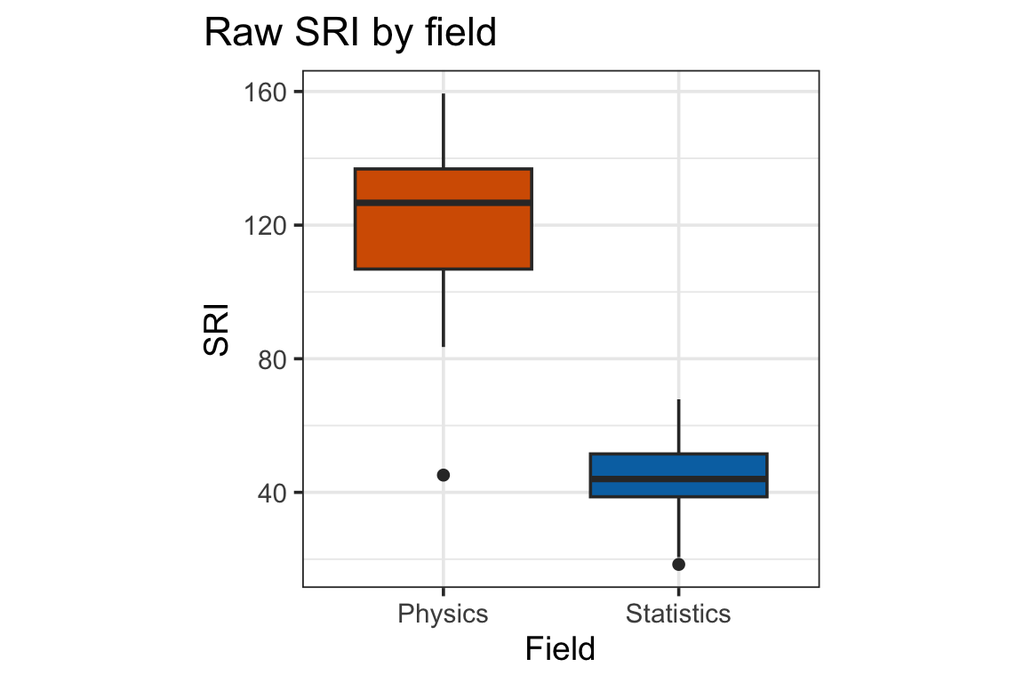

```r
ggplot(sri_data, aes(x = field, y = sri, fill = field)) +
  geom_boxplot(show.legend = FALSE) +
  labs(
    title = "Raw SRI by field",
    x = "Field", y = "SRI"
  )
```

Physics has substantially higher raw SRI values (median around 120) compared to Statistics (median around 45).

**b.**

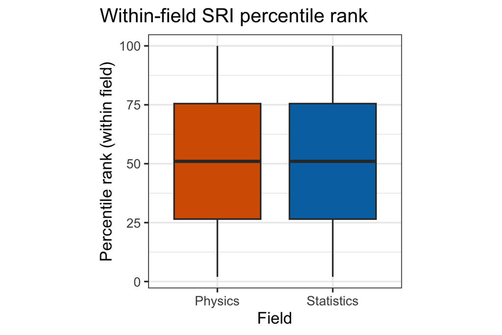

```r
sri_data <- sri_data |>
  group_by(field) |>
  mutate(pct_rank = rank(sri) / n() * 100) |>
  ungroup()

ggplot(sri_data, aes(x = field, y = pct_rank, fill = field)) +
  geom_boxplot(show.legend = FALSE) +
  labs(
    title = "Within-field SRI percentile rank",
    x = "Field", y = "Percentile rank (within field)"
  )
```

Once we standardise within field, both distributions are centred near the 50th percentile — as expected for a uniform ranking. The apparent advantage of Physics disappears; what remains is each department’s standing *within its own peer group*.

**c.**

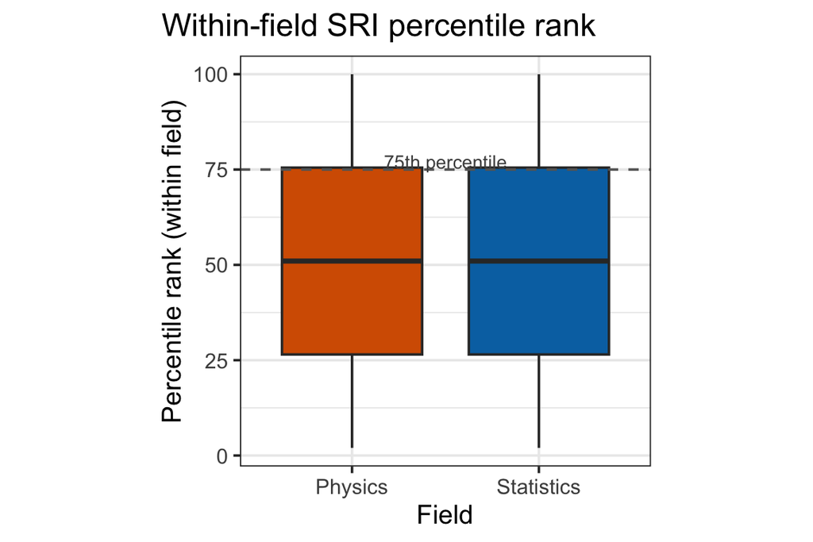

```r
ggplot(sri_data, aes(x = field, y = pct_rank, fill = field)) +
  geom_boxplot(show.legend = FALSE) +
  geom_hline(yintercept = 75, linetype = "dashed", colour = "grey40") +
  annotate("text", x = 1.5, y = 77, label = "75th percentile", size = 3.5, colour = "grey30") +
  labs(
    title = "Within-field SRI percentile rank",
    x = "Field", y = "Percentile rank (within field)"
  )
```

The raw SRI boxplot does *not* communicate this equally well. Seeing that Statistics has a median raw SRI of ~45 while Physics has ~120 gives no indication that the Statistics department is near the top quarter of Statistics departments nationally. The percentile plot makes this performance visible at a glance.

#### 3. “All departments are treated the same” — fact or fiction?

The seminar documents a striking pattern: when the same SRI shift metric (change in SRI relative to a Public AAU benchmark) is applied to different types of departments, the implicit comparison is not equivalent across fields.

Consider the following claim made by university administrators:

> “All departments are treated equally — the same metrics and the same thresholds are applied to everyone.”
1. Using the concept of **mixture distributions** discussed in the seminar, explain why applying a single threshold to all departments does *not* treat them equally, even if the rule is the same on paper.
2. Sketch (by hand or with `ggplot2`) two normal distributions with different means — one representing a graduate-only program and one a large undergraduate service department — plotted on the same axis. Draw a single vertical threshold line. What proportion of each group falls below the threshold? What does this reveal about the fairness of a uniform cut-off?

**SolutionSolution**

**a.** When departments from structurally different fields are pooled into one distribution, the mean and variance of that mixture reflect the norms of the most common or most productive field types, not the norms of each individual field. A single threshold therefore effectively judges every department against the norms of the dominant group. A small, graduate-only humanities department operating entirely within normal parameters for its type will appear to underperform relative to a large engineering department, simply because the mixture distribution is skewed toward large-department metrics. Equal rules applied to an unequal mixture produce unequal outcomes.

**b.**

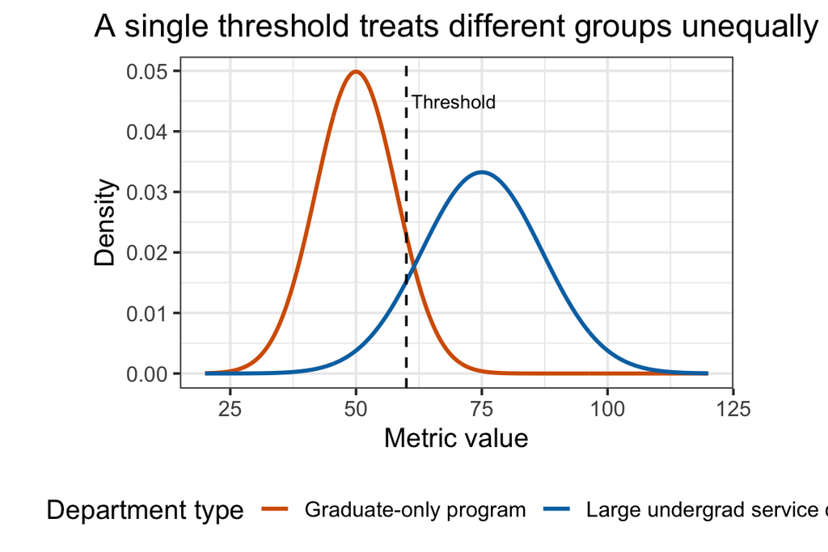

```r
threshold <- 60

dist_data <- tibble(
  x     = seq(20, 120, length.out = 500),
  grad  = dnorm(x, mean = 50, sd = 8),
  undergrad = dnorm(x, mean = 75, sd = 12)
) |>
  pivot_longer(c(grad, undergrad), names_to = "type", values_to = "density") |>
  mutate(type = recode(type,
                       grad = "Graduate-only program",
                       undergrad = "Large undergrad service dept"))

ggplot(dist_data, aes(x = x, y = density, colour = type)) +
  geom_line(linewidth = 1) +
  geom_vline(xintercept = threshold, linetype = "dashed") +
  annotate("text", x = threshold + 1, y = 0.045,
           label = "Threshold", hjust = 0, size = 3.5) +
  labs(
    title = "A single threshold treats different groups unequally",
    x = "Metric value", y = "Density",
    colour = "Department type"
  ) +
  theme(aspect.ratio = 0.6, legend.position = "bottom")
```

```r
# Approximate proportions below the threshold
pnorm(threshold, mean = 50, sd = 8)       # grad-only
```

```
[1] 0.89
```

```r
pnorm(threshold, mean = 75, sd = 12)      # undergrad service
```

```
[1] 0.11
```

#### 4. Using performance gaps constructively

The seminar’s *Missed Opportunity* slide proposes reframing the SRI gap between a university’s departments and the Public AAU benchmark:

Rather than using a negative gap as grounds for programme elimination, this gap could guide **targeted investment**.

1. Using the simulated data below, create a dot plot of `sri_gap` for each department, coloured by whether the gap is positive (above AAU benchmark) or negative (below benchmark). Sort departments by gap size.
2. Which departments might benefit most from investment, according to this framing? Is a large negative gap alone sufficient information to make that decision? What else would you want to know?

```r
set.seed(7)

investment_data <- tibble(
  department = c("Statistics", "Physics", "English", "Ed Admin",
                 "Agronomy", "Music", "Classics", "Civil Eng",
                 "Economics", "Sociology"),
  sri_gap    = c(-12, 8, -25, -40, 5, -18, -30, 15, -8, -22)
)
```

**SolutionSolution**

**a.**

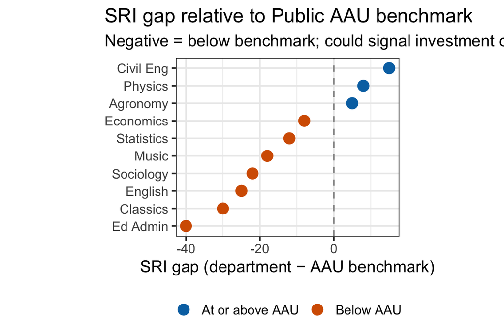

```r
investment_data |>
  mutate(
    department = fct_reorder(department, sri_gap),
    direction  = if_else(sri_gap >= 0, "At or above AAU", "Below AAU")
  ) |>
  ggplot(aes(x = sri_gap, y = department, colour = direction)) +
  geom_vline(xintercept = 0, colour = "grey60", linetype = "dashed") +
  geom_point(size = 4) +
  scale_colour_manual(values = c("At or above AAU" = "#0072B2",
                                  "Below AAU"       = "#D55E00")) +
  labs(
    title    = "SRI gap relative to Public AAU benchmark",
    subtitle = "Negative = below benchmark; could signal investment opportunity",
    x        = "SRI gap (department − AAU benchmark)",
    y        = NULL,
    colour   = NULL
  ) +
  theme(aspect.ratio = 0.8, legend.position = "bottom")
```

However, a large negative gap alone is *not* sufficient to decide where to invest. Additional information you would want includes:

- **Within-field percentile**: Is the gap large because the department is performing poorly *within its field*, or because its field has lower AAU representation overall?
- **Trajectory**: Is the gap growing or shrinking over time? A department closing its gap quickly may need less intervention than one widening its gap.
- **Department size and resources**: A small department with few faculty members will naturally have lower raw SRI. Normalising by faculty count changes the picture.
- **Strategic fit**: Does investment in this area align with institutional priorities and student demand?

Using the gap as a *diagnostic* rather than a *verdict* is the constructive approach the seminar advocates.